# DATA 607 - Document Classification

Warner Alexis

2023-11-19

## Document Classification

We are provided with a list of corpus that contains Spam and Ham emails files `(https://spamassassin.apache.org/old/publiccorpus/)` and instructions on how to download. we prefer to use Studio systematic files download so everyone can run the script. We are going to use the tm package which contains function NLP functions.

We are going to implement the following the steps: 1. Download and Load the data 2. Transform the data into Corpus 3. Model Development 3. Prediction

We use this code to download the files and load in R.

#Loading and Downloading the files url_ham <- “https://spamassassin.apache.org/old/publiccorpus/20021010_easy_ham.tar.bz2” url_spam <- “https://spamassassin.apache.org/old/publiccorpus/20021010_spam.tar.bz2”

download.file(url_ham, destfile = “ham.tar.bz2”) download.file(url_spam, destfile = “spam.tar.bz2”) untar(“spam.tar.bz2”, exdir = “spam”) untar(“ham.tar.bz2”, exdir = “ham”)

This will stop our Rm markdown after running once and freeze.

```r
# Download and Load the data
library(tm)
library(caret)
library(e1071)
library(tidyverse)
```

```r
library(wordcloud)
library(naivebayes)
library(tm)
library(SnowballC)
library(caret)
library(gbm)
library(e1071)

#Loading and Downloading the files


# Read the data in the folder we save them
spam_path <- "spam/"
ham_path <- "ham/easy_ham/"
spam_path <- spam_path[which(spam_path!="cmds")]
ham_path <- ham_path[which(ham_path!="cmds")]
```

## Transform the data into Corpus

The data analysis step involves creating a corpus and tidy the data into a data frane so the algorithm can run it. We are going to bind both ham and spam corpus and turn them into a data set. It is very important to create a test set and training set.

```r
# Creating the text Corpus
spam <- Corpus(DirSource(spam_path))
ham <- Corpus(DirSource(ham_path))

# #Lets see what inside each email corpus
meta(spam[[1]])
```

```
##   author       : character(0)
##   datetimestamp: 2023-11-20 04:05:14
##   description  : character(0)
##   heading      : character(0)
##   id           : 00001.7848dde101aa985090474a91ec93fcf0
##   language     : en
##   origin       : character(0)
```

```r
meta(ham[[1]])
```

```
##   author       : character(0)
##   datetimestamp: 2023-11-20 04:05:14
##   description  : character(0)
##   heading      : character(0)
##   id           : 0001.ea7e79d3153e7469e7a9c3e0af6a357e
##   language     : en
##   origin       : character(0)
```

```r
# create function to remove punctuation , common stop words , covert text to lower
## remove any unnecessary character with numbers
spam_tidy <- function(doc){
  doc <- tm_map(doc, content_transformer(tolower))
  doc <- tm_map(doc, content_transformer(PlainTextDocument))
  doc <- tm_map(doc, content_transformer(removePunctuation))
  doc <- tm_map(doc, content_transformer(tolower))
  doc <- tm_map(doc,content_transformer(removeNumbers))
  doc <- tm_map(doc, content_transformer(stemDocument),  language = 'english')
  #doc <- tm_map(doc, removeWords, c('receiv', stopwords('english')))
  doc <- tm_map(doc, removeWords, c('spamassassin', stopwords('english')))
  doc <- tm_map(doc, stripWhitespace)

  return(doc)

}

# use function for both spam and ham
spam_corpus <- spam_tidy(spam)
spam_corpus
```

```
## <<SimpleCorpus>>
## Metadata:  corpus specific: 1, document level (indexed): 0
## Content:  documents: 501
```

```r
easy_ham_corpus <- spam_tidy(ham)
easy_ham_corpus
```

```
## <<SimpleCorpus>>
## Metadata:  corpus specific: 1, document level (indexed): 0
## Content:  documents: 2551
```

```r
# create the ham and spam corpus
ham_or_spam_corpus <- c(easy_ham_corpus, spam_corpus)
tdm <- DocumentTermMatrix(ham_or_spam_corpus)
tdm
```

```
## <<DocumentTermMatrix (documents: 6, terms: 59472)>>
## Non-/sparse entries: 64479/292353
## Sparsity           : 82%
## Maximal term length: 298
## Weighting          : term frequency (tf)
```

```r
inspect(tdm)
```

```
## <<DocumentTermMatrix (documents: 6, terms: 59472)>>
## Non-/sparse entries: 64479/292353
## Sparsity           : 82%
## Maximal term length: 298
## Weighting          : term frequency (tf)
## Sample             :
##     Terms
## Docs  aug esmtp  ist localhost  mon  oct postfix receiv   sep  thu
##    1 5179  8710 4389      7602 3869 5456    4825  14477 10008 4224
##    2    0     0    0         0    0    0       0      0     0    0
##    3    0     0    0         0    0    0       0      0     0    0
##    4 1173  1118  740      1178  674   56     595   2890  2128  486
##    5    0     0    0         0    0    0       0      0     0    0
##    6    0     0    0         0    0    0       0      0     0    0
```

```r
# see top 10 words in both spam ham combine
# Summary Statistics

freq <- tdm %>% as.matrix() %>% colSums()
length(freq)
```

```
## [1] 59472
```

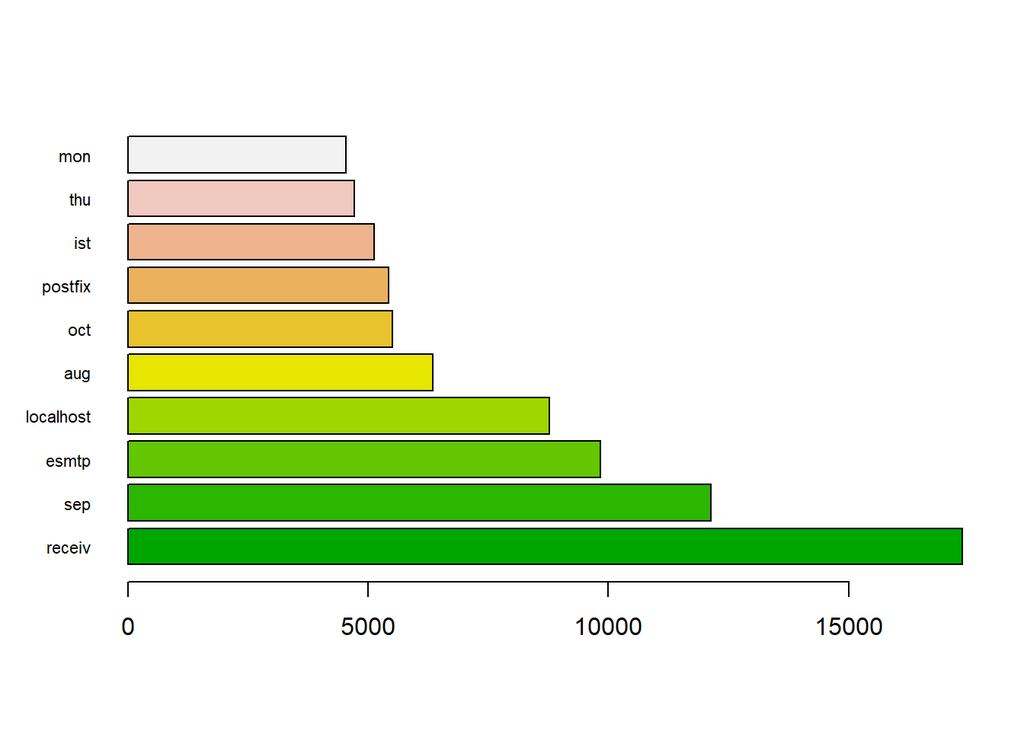

```r
freq_ord <- freq %>% order(decreasing = TRUE)
par(las=1)
#This will create a bar plot of the top 10 words in the spam Corpus
barplot(freq[freq_ord[1:10]], horiz = TRUE, col=terrain.colors(10), cex.names=0.7)
```

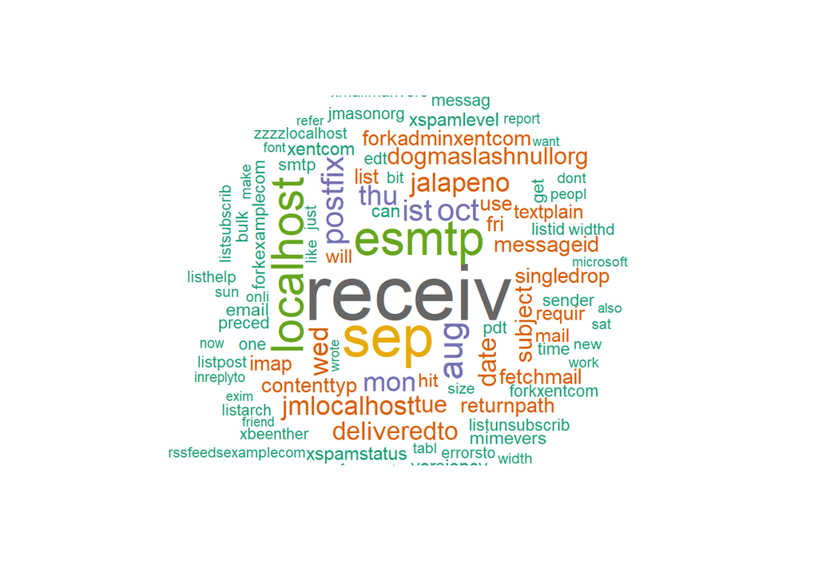

```r
# Let see combinaison of  100 words that appears in both ham and spam
wordcloud(ham_or_spam_corpus, max.words = 100, random.order = FALSE, rot.per=0.15, min.freq=5, colors = brewer.pal(8, "Dark2"))
```

## Model Development

```r
# model development
# adding text and email columns to the data set
df_ham <- as.data.frame(unlist(easy_ham_corpus), stringsAsFactors = FALSE)
df_ham$type <- "ham"
colnames(df_ham)=c("text", "email")


df_spam <- as.data.frame(unlist(spam_corpus), stringsAsFactors = FALSE)
df_spam$type <- "spam"
colnames(df_spam)=c("text", "email")

df_ham_or_spam <- rbind(df_ham, df_spam)

head(df_ham_or_spam)
```

```
##                                                                                                                                                                                                                                                                                                          …
## content1  exmhworkersadminredhatcom thu aug returnpath exmhworkersadminexamplecom deliveredto zzzzlocalhostnetnoteinccom receiv localhost localhost phoboslabsnetnoteinccom postfix esmtp id dec zzzzlocalhost thu aug edt receiv phobo localhost imap fetchmail zzzzlocalhost singledrop thu aug ist rec…
## content2                                                                                                                                                                                                                                                                                                 …
## content3                                                                                                                                                                                                                                                                                                 …
## content4                                                                                                                                                                                                                                                                                                 …
## content5                                                                                                           exmhusersadminredhatcom thu aug returnpath exmhusersadminexamplecom deliveredto zzzzlocalhostnetnoteinccom receiv localhost localhost phoboslabsnetnoteinccom postfix esmtp id bc zzzz…
## content6                                                                                                                                                                                                                                                                                                 …
##          email
## content1   ham
## content2   ham
## content3   ham
## content4   ham
## content5   ham
## content6   ham
```

```r
# Split data
set.seed(250)
df_ham_or_spam$text[df_ham_or_spam$text==""] <- "NaN"
train_index <- createDataPartition(df_ham_or_spam$email, p=0.80, list=FALSE)
email_train <- df_ham_or_spam[train_index,]
email_test <- df_ham_or_spam[-train_index,]


#Create corpus for training and test data
train_email_corpus <- Corpus(VectorSource(email_train$text))
test_email_corpus <- Corpus(VectorSource(email_test$text))

train_clean_corpus <- tm_map(train_email_corpus ,removeNumbers)
test_clean_corpus <- tm_map(test_email_corpus,removeNumbers)

train_clean_corpus <- tm_map(train_clean_corpus,removePunctuation)
test_clean_corpus <- tm_map(test_clean_corpus,removePunctuation)

train_clean_corpus <- tm_map(train_clean_corpus,removeWords,stopwords())
test_clean_corpus  <- tm_map(test_clean_corpus,removeWords, stopwords())

train_clean_corpus<- tm_map(train_clean_corpus,stripWhitespace)
test_clean_corpus<- tm_map(test_clean_corpus,stripWhitespace)

train_email_dtm <- DocumentTermMatrix(train_clean_corpus)
test_email_dtm <- DocumentTermMatrix(test_clean_corpus )
```

After Creating the training and testing set, we are going to add o and 1 to both of the sets and create the model. Training set contains 80% of the combines ham and spam and the rest goes to test set.

```r
# Here I'm defining input variables 0 and 1 from string to integer
convert_count <- function(x) {
  y <- ifelse(x > 0, 1,0)
  y <- factor(y, levels=c(0,1), labels=c(0,1))
  y
}


train_sms <- apply(train_email_dtm, 2, convert_count)
test_sms <- apply(test_email_dtm, 2, convert_count)


# NaiveBayes Model:
classifier <- naiveBayes(train_sms, factor(email_train$email))
test_pred <- predict(classifier, newdata=test_sms)

cm <- table(test_pred, email_test$email)
summary(classifier)
```

```
##           Length Class  Mode
## apriori       2  table  numeric
## tables    47073  -none- list
## levels        2  -none- character
## isnumeric 47073  -none- logical
## call          3  -none- call
```

```r
confusionMatrix(cm)
```

```
## Confusion Matrix and Statistics
##
##
## test_pred ham spam
##      ham  510    1
##      spam   0   99
##
##                Accuracy : 0.9984
##                  95% CI : (0.9909, 1)
##     No Information Rate : 0.8361
##     P-Value [Acc > NIR] : <2e-16
##
##                   Kappa : 0.994
##
##  Mcnemar's Test P-Value : 1
##
##             Sensitivity : 1.0000
##             Specificity : 0.9900
##          Pos Pred Value : 0.9980
##          Neg Pred Value : 1.0000
##              Prevalence : 0.8361
##          Detection Rate : 0.8361
##    Detection Prevalence : 0.8377
##       Balanced Accuracy : 0.9950
##
##        'Positive' Class : ham
##
```

## Conclusion

we are able to use classified ham and spam loaded from `(https://spamassassin.apache.org/old/publiccorpus/)`. Our most significant challenge were the equipment we used. we need more GPU power to run the Naive Bayes model. This is was a very good assignment. It is added significant knowledge on how to do classification problem. We can agree that 99% of spam emails has been corectly classified.

## References

1. GeeksforGeeks. (2021, July 13). Naive Bayes classifier in R programming. GeeksforGeeks. https://www.geeksforgeeks.org/naive-bayes-classifier-in-r-programming/
2. Kasper Welbers, Wouter Van Atteveldt & Kenneth Benoit Text Analysis in R. (n.d.). https://eprints.lse.ac.uk/86659/1/Benoit_Text%20analysis%20in%20R_2018.pdf
3. Public Corpus https://spamassassin.apache.org/old/publiccorpus/